# Extraction de données

```python
df.head()
```

|  | rank | nat_sail | skipper_crew | hour_FR | latitude | longitude | heading_since_30mn | speed_since_30mn | VMG_since_30mn | distance_since_30mn | ... | speed_since_last | VMG_since_last | distance_since_last | heading_since_24hr | speed_since_24hr | VMG_since_24hr | distance_since_24hr | DTF | DTL | date_hours |
| --- | --- | --- | --- | --- | --- | --- | --- | --- | --- | --- | --- | --- | --- | --- | --- | --- | --- | --- | --- | --- | --- |
| 0 | 1 | \nFRA 18 | Louis Burton\nBureau Vallée 2 | 15:30 FR\n | 46°24.46'N | 01°50.48'W | 241° | 17.7 kts | 17.5 kts | 0.3 nm | ... | 0.0 kts | 0.0 kts | 2788.0 nm | 201° | 0.3 kts | 0.3 kts | 6.1 nm | 24293.9 nm | 0.0 nm | 2020-11-08_14:00:00 |
| 1 | 2 | \nMON 10 | Boris Herrmann\nSeaexplorer - Yacht Club De Mo... | 15:31 FR\n1min | 46°24.34'N | 01°49.82'W | 241° | 11.1 kts | 10.9 kts | 0.4 nm | ... | 0.0 kts | 0.0 kts | 2787.9 nm | 196° | 0.3 kts | 0.2 kts | 6.0 nm | 24294.2 nm | 0.4 nm | 2020-11-08_14:00:00 |
| 2 | 3 | \nFRA 8 | Jérémie Beyou\nCharal | 15:30 FR\n | 46°24.91'N | 01°49.99'W | 244° | 15.5 kts | 15.5 kts | 0.5 nm | ... | 0.0 kts | 0.0 kts | 2788.5 nm | 199° | 0.2 kts | 0.2 kts | 5.5 nm | 24294.3 nm | 0.5 nm | 2020-11-08_14:00:00 |
| 3 | 4 | \nFRA 59 | Thomas Ruyant\nLinkedOut | 15:30 FR\n | 46°24.71'N | 01°49.68'W | 244° | 13.2 kts | 13.1 kts | 0.7 nm | ... | 0.0 kts | 0.0 kts | 2788.3 nm | 196° | 0.2 kts | 0.2 kts | 5.6 nm | 24294.5 nm | 0.6 nm | 2020-11-08_14:00:00 |
| 4 | 5 | \nFRA 53 | Maxime Sorel\nV And B Mayenne | 15:30 FR\n | 46°24.59'N | 01°49.56'W | 246° | 10.9 kts | 10.9 kts | 0.2 nm | ... | 0.0 kts | 0.0 kts | 2788.1 nm | 195° | 0.8 kts | 0.7 kts | 5.8 nm | 24294.5 nm | 0.6 nm | 2020-11-08_14:00:00 |

5 rows × 21 columns

```python
df.describe()
```

|  | rank | nat_sail | skipper_crew | hour_FR | latitude | longitude | heading_since_30mn | speed_since_30mn | VMG_since_30mn | distance_since_30mn | ... | speed_since_last | VMG_since_last | distance_since_last | heading_since_24hr | speed_since_24hr | VMG_since_24hr | distance_since_24hr | DTF | DTL | date_hours |
| --- | --- | --- | --- | --- | --- | --- | --- | --- | --- | --- | --- | --- | --- | --- | --- | --- | --- | --- | --- | --- | --- |
| count | 12144 | 12144 | 12144 | 10831 | 10831 | 10831 | 10831 | 10831 | 10831 | 10831 | ... | 10831 | 10831 | 10831 | 10831 | 10831 | 10831 | 10831 | 10831 | 10831 | 12144 |
| unique | 67 | 33 | 34 | 41 | 10392 | 10506 | 344 | 236 | 295 | 138 | ... | 229 | 273 | 1269 | 283 | 213 | 244 | 3386 | 10223 | 8533 | 362 |
| top | RET | \nFRA 18 | Louis Burton\nBureau Vallée 2 | 14:30 FR\n | 46°30.11'N | 01°47.45'W | 90° | 15.3 kts | 12.0 kts | 6.9 nm | ... | 13.5 kts | 13.0 kts | 44.8 nm | 86° | 14.2 kts | 13.0 kts | 0.0 nm | 24245.3 nm | 0.0 nm | 2020-11-08_17:00:00 |
| freq | 1307 | 368 | 368 | 1559 | 19 | 19 | 145 | 128 | 102 | 227 | ... | 125 | 121 | 43 | 188 | 132 | 122 | 18 | 19 | 368 | 66 |

4 rows × 21 columns

```python
df.dtypes
```

```
rank                   object
nat_sail               object
skipper_crew           object
hour_FR                object
latitude               object
longitude              object
heading_since_30mn     object
speed_since_30mn       object
VMG_since_30mn         object
distance_since_30mn    object
heading_since_last     object
speed_since_last       object
VMG_since_last         object
distance_since_last    object
heading_since_24hr     object
speed_since_24hr       object
VMG_since_24hr         object
distance_since_24hr    object
DTF                    object
DTL                    object
date_hours             object
dtype: object
```

conversion et nettoyage du dataframe

```python
df.columns
```

```
Index(['rank', 'nat_sail', 'skipper_crew', 'hour_FR', 'latitude', 'longitude',
       'heading_since_30mn', 'speed_since_30mn', 'VMG_since_30mn',
       'distance_since_30mn', 'heading_since_last', 'speed_since_last',
       'VMG_since_last', 'distance_since_last', 'heading_since_24hr',
       'speed_since_24hr', 'VMG_since_24hr', 'distance_since_24hr', 'DTF',
       'DTL', 'heure_bis'],
      dtype='object')
```

```python
df.head()
```

|  | rank | nat_sail | skipper_crew | hour_FR | latitude | longitude | heading_since_30mn | speed_since_30mn | VMG_since_30mn | distance_since_30mn | ... | speed_since_last | VMG_since_last | distance_since_last | heading_since_24hr | speed_since_24hr | VMG_since_24hr | distance_since_24hr | DTF | DTL | heure_bis |
| --- | --- | --- | --- | --- | --- | --- | --- | --- | --- | --- | --- | --- | --- | --- | --- | --- | --- | --- | --- | --- | --- |
| 0 | 1 | \nFRA 18 | Louis Burton\nBureau Vallée 2 | 15:30 FR\n | 46°24.46'N | 01°50.48'W | 241° | 17.7 kts | 17.5 kts | 0.3 nm | ... | 0.0 kts | 0.0 kts | 2788.0 nm | 201° | 0.3 kts | 0.3 kts | 6.1 nm | 24293.9 nm | 0.0 nm | 2020-11-08_14:00:00 |
| 1 | 2 | \nMON 10 | Boris Herrmann\nSeaexplorer - Yacht Club De Mo... | 15:31 FR\n1min | 46°24.34'N | 01°49.82'W | 241° | 11.1 kts | 10.9 kts | 0.4 nm | ... | 0.0 kts | 0.0 kts | 2787.9 nm | 196° | 0.3 kts | 0.2 kts | 6.0 nm | 24294.2 nm | 0.4 nm | 2020-11-08_14:00:00 |
| 2 | 3 | \nFRA 8 | Jérémie Beyou\nCharal | 15:30 FR\n | 46°24.91'N | 01°49.99'W | 244° | 15.5 kts | 15.5 kts | 0.5 nm | ... | 0.0 kts | 0.0 kts | 2788.5 nm | 199° | 0.2 kts | 0.2 kts | 5.5 nm | 24294.3 nm | 0.5 nm | 2020-11-08_14:00:00 |
| 3 | 4 | \nFRA 59 | Thomas Ruyant\nLinkedOut | 15:30 FR\n | 46°24.71'N | 01°49.68'W | 244° | 13.2 kts | 13.1 kts | 0.7 nm | ... | 0.0 kts | 0.0 kts | 2788.3 nm | 196° | 0.2 kts | 0.2 kts | 5.6 nm | 24294.5 nm | 0.6 nm | 2020-11-08_14:00:00 |
| 4 | 5 | \nFRA 53 | Maxime Sorel\nV And B Mayenne | 15:30 FR\n | 46°24.59'N | 01°49.56'W | 246° | 10.9 kts | 10.9 kts | 0.2 nm | ... | 0.0 kts | 0.0 kts | 2788.1 nm | 195° | 0.8 kts | 0.7 kts | 5.8 nm | 24294.5 nm | 0.6 nm | 2020-11-08_14:00:00 |

5 rows × 21 columns

```python
df
```

|  | rank | nat_sail | hour_FR | latitude | longitude | heading_since_30_mn | speed_since_30_mn | VMG_since_30_mn | distance_since_30_mn | heading_since_last_report | ... | distance_since_last_report | heading_since_24_hr | speed_since_24_hr | VMG_since_24_hr | distance_since_24_hr | DTF | DTL | heure_bis | Skipper | Crew |
| --- | --- | --- | --- | --- | --- | --- | --- | --- | --- | --- | --- | --- | --- | --- | --- | --- | --- | --- | --- | --- | --- |
| 0 | 1 | FRA 18 | 15:30 | 46°24.46'N | 01°50.48'W | 241 | 17.7 | 17.5 | 0.3 nm | 357 | ... | 2788.0 nm | 201 | 0.3 | 0.3 | 6.1 nm | 24293.9 nm | 0.0 nm | 2020-11-08_14:00:00 | Louis Burton | Bureau Vallée 2 |
| 1 | 2 | MON 10 | 15:31 1min | 46°24.34'N | 01°49.82'W | 241 | 11.1 | 10.9 | 0.4 nm | 357 | ... | 2787.9 nm | 196 | 0.3 | 0.2 | 6.0 nm | 24294.2 nm | 0.4 nm | 2020-11-08_14:00:00 | Boris Herrmann | Seaexplorer - Yacht Club De Monaco |
| 2 | 3 | FRA 8 | 15:30 | 46°24.91'N | 01°49.99'W | 244 | 15.5 | 15.5 | 0.5 nm | 357 | ... | 2788.5 nm | 199 | 0.2 | 0.2 | 5.5 nm | 24294.3 nm | 0.5 nm | 2020-11-08_14:00:00 | Jérémie Beyou | Charal |
| 3 | 4 | FRA 59 | 15:30 | 46°24.71'N | 01°49.68'W | 244 | 13.2 | 13.1 | 0.7 nm | 357 | ... | 2788.3 nm | 196 | 0.2 | 0.2 | 5.6 nm | 24294.5 nm | 0.6 nm | 2020-11-08_14:00:00 | Thomas Ruyant | LinkedOut |
| 4 | 5 | FRA 53 | 15:30 | 46°24.59'N | 01°49.56'W | 246 | 10.9 | 10.9 | 0.2 nm | 357 | ... | 2788.1 nm | 195 | 0.8 | 0.7 | 5.8 nm | 24294.5 nm | 0.6 nm | 2020-11-08_14:00:00 | Maxime Sorel | V And B Mayenne |
| ... | ... | ... | ... | ... | ... | ... | ... | ... | ... | ... | ... | ... | ... | ... | ... | ... | ... | ... | ... | ... | ... |
| 12139 | RET | FRA 109 | NaN | NaN | NaN | NaN | NaN | NaN | NaN | NaN | ... | NaN | NaN | NaN | NaN | NaN | NaN | NaN | 2021-01-07_14:00:00 | Samantha Davies | Initiatives - Coeur |
| 12140 | RET | FRA 4 | NaN | NaN | NaN | NaN | NaN | NaN | NaN | NaN | ... | NaN | NaN | NaN | NaN | NaN | NaN | NaN | 2021-01-07_14:00:00 | Sébastien Simon | ARKEA PAPREC |
| 12141 | RET | GBR 99 | NaN | NaN | NaN | NaN | NaN | NaN | NaN | NaN | ... | NaN | NaN | NaN | NaN | NaN | NaN | NaN | 2021-01-07_14:00:00 | Alex Thomson | HUGO BOSS |
| 12142 | RET | FRA 85 | NaN | NaN | NaN | NaN | NaN | NaN | NaN | NaN | ... | NaN | NaN | NaN | NaN | NaN | NaN | NaN | 2021-01-07_14:00:00 | Kevin Escoffier | PRB |
| 12143 | RET | FRA 6 | NaN | NaN | NaN | NaN | NaN | NaN | NaN | NaN | ... | NaN | NaN | NaN | NaN | NaN | NaN | NaN | 2021-01-07_14:00:00 | Nicolas Troussel | CORUM L'Épargne |

12144 rows × 22 columns

```python
df.tail(30)
```

|  | rank | nat_sail | hour_FR | latitude | longitude | heading_since_30_mn | speed_since_30_mn | VMG_since_30_mn | distance_since_30_mn | heading_since_last_report | ... | distance_since_last_report | heading_since_24_hr | speed_since_24_hr | VMG_since_24_hr | distance_since_24_hr | DTF | DTL | heure_bis | Skipper | Crew |
| --- | --- | --- | --- | --- | --- | --- | --- | --- | --- | --- | --- | --- | --- | --- | --- | --- | --- | --- | --- | --- | --- |
| 12102 | 25 | FRA 72 | 11:30 | 54°30.15'S | 179°17.36'E | 59 | 7.7 | 5.5 | 3.9 | 60 | ... | 21.8 | 87 | 9.8 | 9.3 | 234.7 | 10883.6 | 5272.4 | 2021-01-07_11:00:00 | Alexia Barrier | TSE - 4myplanet |
| 12103 | 26 | FIN 222 | 11:30 | 50°24.54'S | 173°44.76'E | 84 | 13.2 | 11.2 | 6.6 | 85 | ... | 27.7 | 67 | 10.6 | 7.0 | 255.4 | 11160.0 | 5548.8 | 2021-01-07_11:00:00 | Ari Huusela | Stark |
| 12104 | 27 | FRFRA 69 | 11:30 | 49°58.17'S | 128°26.52'E | 112 | 11.5 | 11.4 | 5.8 | 160 | ... | 35.9 | 157 | 10.8 | 9.5 | 259.0 | 12693.0 | 7081.8 | 2021-01-07_11:00:00 | Sébastien Destremau | Merci |
| 12111 | 1 | FRA 17 | 14:30 | 37°08.41'S | 44°22.22'W | 360 | 17.1 | 15.5 | 8.6 | 3 | ... | 52.5 | 10 | 16.5 | 15.9 | 396.8 | 5562.4 | 0.0 | 2021-01-07_14:00:00 | Yannick Bestaven | Maître Coq IV |
| 12112 | 2 | FRA 59 | 14:30 | 42°07.49'S | 52°32.62'W | 0 | 16.3 | 14.1 | 8.1 | 357 | ... | 46.5 | 355 | 11.5 | 9.4 | 275.7 | 6002.0 | 439.5 | 2021-01-07_14:00:00 | Thomas Ruyant | LinkedOut |
| 12113 | 3 | FRA 79 | 14:30 | 42°31.36'S | 51°40.99'W | 10 | 15.5 | 14.7 | 7.8 | 4 | ... | 40.2 | 347 | 10.8 | 8.0 | 258.6 | 6003.7 | 441.3 | 2021-01-07_14:00:00 | Charlie Dalin | APIVIA |
| 12114 | 4 | FRA 1000 | 14:30 | 46°16.12'S | 42°44.45'W | 65 | 9.6 | 7.2 | 4.8 | 66 | ... | 26.7 | 43 | 8.1 | 7.7 | 194.0 | 6031.8 | 469.4 | 2021-01-07_14:00:00 | Damien Seguin | Groupe APICIL |
| 12115 | 5 | FRA 18 | 14:30 | 47°33.52'S | 43°41.14'W | 59 | 11.5 | 9.5 | 5.7 | 62 | ... | 33.7 | 50 | 10.5 | 9.7 | 251.8 | 6118.3 | 555.9 | 2021-01-07_14:00:00 | Louis Burton | Bureau Vallée 2 |
| 12116 | 6 | FRA 09 | 14:30 | 47°30.42'S | 46°53.78'W | 71 | 11.2 | 8.0 | 5.6 | 74 | ... | 36.8 | 54 | 10.3 | 9.4 | 247.8 | 6171.7 | 609.3 | 2021-01-07_14:00:00 | Benjamin Dutreux | OMIA - Water Family |
| 12117 | 7 | FRA 01 | 14:30 | 48°18.85'S | 45°31.75'W | 54 | 12.5 | 11.0 | 6.2 | 62 | ... | 32.8 | 47 | 12.3 | 11.8 | 294.6 | 6190.9 | 628.5 | 2021-01-07_14:00:00 | Jean Le Cam | Yes we Cam ! |
| 12118 | 8 | ITA 34 | 14:30 | 48°50.85'S | 47°02.20'W | 57 | 10.3 | 8.9 | 5.2 | 54 | ... | 32.0 | 52 | 12.9 | 12.1 | 309.1 | 6246.1 | 683.7 | 2021-01-07_14:00:00 | Giancarlo Pedote | Prysmian Group |
| 12119 | 9 | MON 10 | 14:30 | 49°21.70'S | 48°44.34'W | 72 | 13.8 | 9.9 | 6.9 | 74 | ... | 38.5 | 58 | 15.0 | 13.7 | 359.9 | 6304.4 | 742.0 | 2021-01-07_14:00:00 | Boris Herrmann | Seaexplorer - Yacht Club De Monaco |
| 12120 | 10 | FRA 53 | 14:30 | 49°33.88'S | 48°31.31'W | 69 | 13.4 | 10.1 | 6.7 | 70 | ... | 37.9 | 62 | 14.0 | 12.2 | 334.9 | 6311.2 | 748.7 | 2021-01-07_14:00:00 | Maxime Sorel | V And B Mayenne |
| 12121 | 11 | FRA 27 | 14:30 | 49°45.67'S | 48°38.03'W | 60 | 10.6 | 9.0 | 5.3 | 62 | ... | 32.2 | 52 | 11.9 | 11.2 | 284.6 | 6323.6 | 761.2 | 2021-01-07_14:00:00 | Isabelle Joschke | MACSF |
| 12122 | 12 | FRA 30 | 14:30 | 53°21.09'S | 59°08.10'W | 31 | 5.3 | 5.3 | 2.6 | 36 | ... | 9.8 | 58 | 9.3 | 8.8 | 223.4 | 6712.3 | 1149.9 | 2021-01-07_14:00:00 | Clarisse Cremer | Banque Populaire X |
| 12123 | 13 | FRFRA 02 | 14:30 | 53°47.87'S | 59°49.57'W | 33 | 0.4 | 0.4 | 0.2 | 63 | ... | 8.5 | 61 | 10.5 | 9.8 | 252.2 | 6748.4 | 1186.0 | 2021-01-07_14:00:00 | Armel Tripon | L'Occitane en Provence |
| 12124 | 14 | FRA 49 | 14:30 | 55°08.01'S | 66°00.21'W | 55 | 8.9 | 8.9 | 4.5 | 35 | ... | 18.8 | 58 | 10.6 | 10.5 | 254.2 | 6946.4 | 1384.0 | 2021-01-07_14:00:00 | Romain Attanasio | Pure - Best Western Hotels and Resorts |
| 12125 | 15 | GBR 777 | 14:30 | 55°40.72'S | 100°57.09'W | 87 | 7.8 | 7.4 | 3.9 | 85 | ... | 24.4 | 72 | 8.5 | 7.1 | 203.7 | 8136.7 | 2574.3 | 2021-01-07_14:00:00 | Pip Hare | Medallia |
| 12126 | 16 | SUI 7 | 14:30 | 56°40.89'S | 102°02.28'W | 100 | 10.9 | 10.9 | 5.4 | 106 | ... | 41.6 | 99 | 13.1 | 13.0 | 314.0 | 8158.7 | 2596.3 | 2021-01-07_14:00:00 | Alan Roura | La Fabrique |
| 12127 | 17 | FRA 14 | 14:30 | 56°39.98'S | 103°14.82'W | 114 | 12.8 | 12.3 | 6.4 | 109 | ... | 39.1 | 95 | 11.9 | 11.8 | 285.1 | 8198.3 | 2635.9 | 2021-01-07_14:00:00 | Arnaud Boissieres | La Mie Câline - Artisans Artipôle |
| 12128 | 18 | FRA 8 | 14:30 | 56°00.06'S | 108°03.34'W | 80 | 15.1 | 13.8 | 7.5 | 76 | ... | 37.9 | 101 | 12.9 | 12.7 | 309.3 | 8363.0 | 2800.6 | 2021-01-07_14:00:00 | Jérémie Beyou | Charal |
| 12129 | 19 | FRA 92 | 14:30 | 53°55.78'S | 115°34.12'W | 125 | 12.1 | 11.9 | 6.1 | 126 | ... | 41.1 | 115 | 11.4 | 11.3 | 272.7 | 8647.8 | 3085.4 | 2021-01-07_14:00:00 | Stéphane Le Diraison | Time For Oceans |
| 12130 | 20 | ESP 33 | 14:30 | 54°23.89'S | 116°57.35'W | 115 | 15.1 | 15.0 | 7.5 | 115 | ... | 41.9 | 128 | 13.8 | 13.7 | 331.2 | 8682.5 | 3120.1 | 2021-01-07_14:00:00 | Didac Costa | One Planet One Ocean |
| 12131 | 21 | JPN 11 | 14:30 | 50°05.99'S | 120°52.29'W | 96 | 11.4 | 10.3 | 5.7 | 53 | ... | 34.3 | 75 | 12.6 | 8.6 | 303.2 | 8928.3 | 3365.9 | 2021-01-07_14:00:00 | Kojiro Shiraishi | DMG MORI Global One |
| 12132 | 22 | FRA 71 | 14:30 | 52°18.98'S | 130°28.60'W | 117 | 15.2 | 15.2 | 7.6 | 113 | ... | 42.0 | 95 | 12.2 | 11.2 | 293.7 | 9175.5 | 3613.1 | 2021-01-07_14:00:00 | Manuel Cousin | Groupe Sétin |
| 12133 | 23 | FRA 50 | 14:30 | 51°51.82'S | 150°30.28'W | 28 | 5.7 | 1.1 | 2.8 | 52 | ... | 18.1 | 58 | 9.2 | 7.1 | 221.7 | 9870.6 | 4308.2 | 2021-01-07_14:00:00 | Miranda Merron | Campagne de France |
| 12134 | 24 | FRA 83 | 14:30 | 52°08.16'S | 151°54.01'W | 80 | 6.5 | 5.9 | 3.2 | 72 | ... | 23.1 | 64 | 9.2 | 7.5 | 221.6 | 9915.6 | 4353.2 | 2021-01-07_14:00:00 | Clément Giraud | Compagnie du lit - Jiliti |
| 12135 | 25 | FRA 72 | 14:30 | 54°19.59'S | 179°56.96'E | 54 | 10.2 | 6.4 | 5.1 | 65 | ... | 25.4 | 83 | 9.0 | 8.4 | 216.3 | 10863.8 | 5301.4 | 2021-01-07_14:00:00 | Alexia Barrier | TSE - 4myplanet |
| 12136 | 26 | FIN 222 | 14:30 | 50°18.66'S | 174°40.49'E | 80 | 11.4 | 9.2 | 5.7 | 80 | ... | 36.1 | 69 | 11.2 | 7.7 | 269.9 | 11130.5 | 5568.1 | 2021-01-07_14:00:00 | Ari Huusela | Stark |
| 12137 | 27 | FRFRA 69 | 14:30 | 49°54.09'S | 128°40.97'E | 38 | 3.2 | 0.4 | 1.6 | 66 | ... | 10.2 | 156 | 9.4 | 8.3 | 224.7 | 12687.1 | 7124.7 | 2021-01-07_14:00:00 | Sébastien Destremau | Merci |

30 rows × 22 columns

```python
#suppression des espaces et des unités
df['nat_sail'] = df['nat_sail'].str.replace("\n","")
#df[['skipper','srew']] = df['skipper_crew'].str.split("\n",expand=True)
#df = df.drop(columns=['skipper_crew'], axis=1)
df['hour_FR'] = df['hour_FR'].str.replace("FR\n","")
df['heading_since_30_mn'] = df['heading_since_30_mn'].str.replace("°","")
df['speed_since_30_mn'] = df['speed_since_30_mn'].str.replace("kts","")
df['VMG_since_30_mn'] = df['VMG_since_30_mn'].str.replace("kts","")
df['distance_since_30_mn'] = df['distance_since_30_mn'].str.replace("nm","")
df['heading_since_24_hr'] = df['heading_since_24_hr'].str.replace("°","")
df['speed_since_24_hr'] = df['speed_since_24_hr'].str.replace("kts","")
df['VMG_since_24_hr'] = df['VMG_since_24_hr'].str.replace("kts","")
df['distance_since_24_hr'] = df['distance_since_24_hr'].str.replace("nm","")
df['heading_since_last_report'] = df['heading_since_last_report'].str.replace("°","")
df['speed_since_last_report'] = df['speed_since_last_report'].str.replace("kts","")
df['VMG_since_last_report'] = df['VMG_since_last_report'].str.replace("kts","")
df['distance_since_last_report'] = df['distance_since_last_report'].str.replace("nm","")
df['DTF'] = df['DTF'].str.replace("nm","")
df['DTL'] = df['DTL'].str.replace("nm","")
df = df[df['rank'].notna()]
```

```python
df.dropna(inplace=True)
```

```python
df
```

|  | rank | nat_sail | hour_FR | latitude | longitude | heading_since_30_mn | speed_since_30_mn | VMG_since_30_mn | distance_since_30_mn | heading_since_last_report | ... | distance_since_last_report | heading_since_24_hr | speed_since_24_hr | VMG_since_24_hr | distance_since_24_hr | DTF | DTL | heure_bis | Skipper | Crew |
| --- | --- | --- | --- | --- | --- | --- | --- | --- | --- | --- | --- | --- | --- | --- | --- | --- | --- | --- | --- | --- | --- |
| 0 | 1 | FRA 18 | 15:30 | 46°24.46'N | 01°50.48'W | 241 | 17.7 | 17.5 | 0.3 | 357 | ... | 2788.0 | 201 | 0.3 | 0.3 | 6.1 | 24293.9 | 0.0 | 2020-11-08_14:00:00 | Louis Burton | Bureau Vallée 2 |
| 1 | 2 | MON 10 | 15:31 1min | 46°24.34'N | 01°49.82'W | 241 | 11.1 | 10.9 | 0.4 | 357 | ... | 2787.9 | 196 | 0.3 | 0.2 | 6.0 | 24294.2 | 0.4 | 2020-11-08_14:00:00 | Boris Herrmann | Seaexplorer - Yacht Club De Monaco |
| 2 | 3 | FRA 8 | 15:30 | 46°24.91'N | 01°49.99'W | 244 | 15.5 | 15.5 | 0.5 | 357 | ... | 2788.5 | 199 | 0.2 | 0.2 | 5.5 | 24294.3 | 0.5 | 2020-11-08_14:00:00 | Jérémie Beyou | Charal |
| 3 | 4 | FRA 59 | 15:30 | 46°24.71'N | 01°49.68'W | 244 | 13.2 | 13.1 | 0.7 | 357 | ... | 2788.3 | 196 | 0.2 | 0.2 | 5.6 | 24294.5 | 0.6 | 2020-11-08_14:00:00 | Thomas Ruyant | LinkedOut |
| 4 | 5 | FRA 53 | 15:30 | 46°24.59'N | 01°49.56'W | 246 | 10.9 | 10.9 | 0.2 | 357 | ... | 2788.1 | 195 | 0.8 | 0.7 | 5.8 | 24294.5 | 0.6 | 2020-11-08_14:00:00 | Maxime Sorel | V And B Mayenne |
| ... | ... | ... | ... | ... | ... | ... | ... | ... | ... | ... | ... | ... | ... | ... | ... | ... | ... | ... | ... | ... | ... |
| 12133 | 23 | FRA 50 | 14:30 | 51°51.82'S | 150°30.28'W | 28 | 5.7 | 1.1 | 2.8 | 52 | ... | 18.1 | 58 | 9.2 | 7.1 | 221.7 | 9870.6 | 4308.2 | 2021-01-07_14:00:00 | Miranda Merron | Campagne de France |
| 12134 | 24 | FRA 83 | 14:30 | 52°08.16'S | 151°54.01'W | 80 | 6.5 | 5.9 | 3.2 | 72 | ... | 23.1 | 64 | 9.2 | 7.5 | 221.6 | 9915.6 | 4353.2 | 2021-01-07_14:00:00 | Clément Giraud | Compagnie du lit - Jiliti |
| 12135 | 25 | FRA 72 | 14:30 | 54°19.59'S | 179°56.96'E | 54 | 10.2 | 6.4 | 5.1 | 65 | ... | 25.4 | 83 | 9.0 | 8.4 | 216.3 | 10863.8 | 5301.4 | 2021-01-07_14:00:00 | Alexia Barrier | TSE - 4myplanet |
| 12136 | 26 | FIN 222 | 14:30 | 50°18.66'S | 174°40.49'E | 80 | 11.4 | 9.2 | 5.7 | 80 | ... | 36.1 | 69 | 11.2 | 7.7 | 269.9 | 11130.5 | 5568.1 | 2021-01-07_14:00:00 | Ari Huusela | Stark |
| 12137 | 27 | FRFRA 69 | 14:30 | 49°54.09'S | 128°40.97'E | 38 | 3.2 | 0.4 | 1.6 | 66 | ... | 10.2 | 156 | 9.4 | 8.3 | 224.7 | 12687.1 | 7124.7 | 2021-01-07_14:00:00 | Sébastien Destremau | Merci |

10831 rows × 22 columns

conversion des données en données numériques

```python
df['rank'] = pd.to_numeric(df['rank'])
df['VMG_since_last_report'] = pd.to_numeric(df['VMG_since_last_report'])
```

```python
df.to_pickle("./df_pickle.pkl")
```

```python
df2.astype(numpy.float64)
```

# Scrapping

scrapping page glosssaire

```python
# imports
import requests
from bs4 import BeautifulSoup
from lxml import etree
```

```python
url = "https://www.vendeeglobe.org/fr/glossaire"
res = requests.get(url)
content = res.content.decode('utf-8')
soup = BeautifulSoup(content)
voilier_name = soup.find_all('div', class_='boats-list__infos')
voilier_carac = soup.find_all('div', {'class': "boats-list__popup-infos"})
```

```python
voilier_infos = [i.text for i in soup.find_all("ul", {"class":"boats-list__popup-specs-list"})]
voilier_name = [i.text.title() for i in soup.find_all("span", {"class":"boats-list__skipper-name"})]
```

```python
tmp = [i.split(" : ") for i in voilier_infos[0].split('\n')[1:-1]]
names = [tmp[i][0] for i in range(len(tmp))]
values = [tmp[i][1] for i in range(len(tmp))]
df_boat = pd.DataFrame([values], columns=names)
```

```python
for j in range(1, len(voilier_infos)):
    tmp = [i.split(" : ") for i in voilier_infos[j].split('\n')[1:-1]]
    names = [tmp[i][0] for i in range(len(tmp))]
    values = [tmp[i][1] for i in range(len(tmp))]
    df_bis = pd.DataFrame([values], columns=names)
    df_boat = df_boat.merge(df_bis, how='outer')
```

```python
voilier_names = [voilier_name[i].title() for i in range(len(voilier_name))]
df_boat['Skipper'] = voilier_names
df_boat.to_pickle("bateaux.pkl")
df_boat.head()
df_boat.dropna(inplace=True)
```

[output not shown]

```python
df_boat['Longueur'] = df_boat['Longueur'].str.replace("m","")
df_boat['Largeur'] = df_boat['Largeur'].str.replace("m","")
df_boat["Tirant d'eau"] = df_boat["Tirant d'eau"].str.replace("m","")
df_boat['Déplacement (poids)'] = df_boat['Déplacement (poids)'].str.replace("t","")
df_boat['Hauteur mât'] = df_boat['Hauteur mât'].str.replace("m","")
df_boat['Surface de voiles au près'] = df_boat['Surface de voiles au près'].str.replace("m2","")
df_boat['Surface de voiles au près'] = df_boat['Surface de voiles au près'].str.replace("m²","")
df_boat['Surface de voiles au portant'] = df_boat['Surface de voiles au portant'].str.replace("m2","")
df_boat['Surface de voiles au portant'] = df_boat['Surface de voiles au portant'].str.replace("m²","")
```

```python
df_boat.dropna(inplace=True)
```

```python
df_boat
```

|  | Numéro de voile | Anciens noms du bateau | Architecte | Chantier | Date de lancement | Longueur | Largeur | Tirant d'eau | Déplacement (poids) | Nombre de dérives | Hauteur mât | Voile quille | Surface de voiles au près | Surface de voiles au portant | Skipper |
| --- | --- | --- | --- | --- | --- | --- | --- | --- | --- | --- | --- | --- | --- | --- | --- |
| 0 | FRA 56 | No Way Back, Vento di Sardegna | VPLP/Verdier | Persico Marine | 01 Août 2015 | 18,28 | 5,85 | 4,50 | 7 | foils | 29 | monotype | 320 | 570 | Fabrice Amedeo |
| 1 | FRA 49 | Gitana Eighty, Synerciel, Newrest-Matmut | Bruce Farr Design | Southern Ocean Marine (Nouvelle Zélande) | 08 Mars 2007 | 18,28 | 5,80 | 4,50 | 9 | 2 | 28 | acier forgé | 280 | 560 | Romain Attanasio |
| 2 | FRA72 | Famille Mary-Etamine du Lys, Initiatives Coeur... | Marc Lombard | MAG France | 01 Mars 1998 | 18,28 | 5,54 | 4,50 | 9 | 2 | 29 | acier | 260 | 580 | Alexia Barrier |
| 3 | 17 | Safran 2 - Des Voiles et Vous | Verdier - VPLP | CDK Technologies | 12 Mars 2015 | 18,28 | 5,80 | 4,50 | 8 | foils | 29 | acier mécano soudé | 310 | 550 | Yannick Bestaven |
| 5 | FRA 14 | Ecover3, Président, Gamesa, Kilcullen Voyager-... | Owen Clarke Design LLP - Clay Oliver | Hakes Marine - Mer Agitée | 03 Août 2007 | 18,28 | 5,65 | 4,50 | 7,9 onnes | foils | 29 | basculante avec vérin | 300 | 610 | Arnaud Boissières |
| 6 | 18 | Banque Populaire VIII | Verdier - VPLP | CDK Technologies | 09 Juin 2015 | 18,28 | 5,80 | 4,50 | 7,6 | foils | 28 | acier | 300 | 600 | Louis Burton |
| 7 | ESP 33 | Kingfisher - Educacion sin Fronteras - Forum M... | Owen Clarke Design | Martens Yachts | 02 Février 2000 | 18,28 | 5,30 | 4,50 | 8,9 | 2 | 26 | acier | 240 | 470 | Didac Costa |
| 8 | FRA 71 | Paprec-Virbac2, Estrella Damm, We are Water, L... | Bruce Farr Yacht Design | Southern Ocean Marine (Nouvelle-Zélande) | 02 Février 2007 | 18,28 | 5,80 | 4,50 | 9 | 2 asymétriques | 28,50 | basculante sur vérin hydraulique | 270 | 560 | Manuel Cousin |
| 9 | FRA30 | Macif - SMA | Verdier - VPLP | CDK - Mer Agitée | 01 Mars 2011 | 18,28 | 5,70 | 4,5 | 7,7 | 2 | 29 | acier forgé | 340 | 570 | Clarisse Cremer |
| 11 | FRA109 | Maître CoQ - Banque Populaire VII- Foncia II | VPLP - Verdier | CDK Technologies | 20 Septembre 2010 | 18,28 | 5,70 | 4,50 | 7,8 | foils | 27 | acier forgé | 300 | 600 | Sam Davies |
| 12 | 69 | Foresight Natural Energy, Maisonneuve | Lavanos | Artech do Brasil | 15 Janvier 2005 | 18,28 | 5,60 | 4,50 | 8,5 | 2 | 29 | acier | 250 | 650 | Sébastien Destremau |
| 13 | FRA09 | Spirit of Yukoh, Neutrogena, Hugo Boss, Estrel... | Bruce Farr Design | Offshore Challenge - Cowes | 03 Juillet 2007 | 18,28 | 5,85 | 4,50 | 8 | 2 | 29 | acier forgé | 300 | 700 | Benjamin Dutreux |
| 15 | FRA83 | Delta Dore, Bureau Vallée, Vers un Monde sans ... | Bruce Farr design | JMV Cherbourg | 26 Juillet 2006 | 18,28 | 5,75 | 4,50 | 8,5 | 2 | 29 | acier forgé | 300 | 620 | Clément Giraud |
| 17 | GBR77 | Armor Lux, We Are Water, La Fabrique | Pierre Rolland | Bernard Stamm | 03 Juillet 1999 | 18,28 | 5,70 | 4,50 | 9 | 2 | 29 | carbone | 300 | 580 | Pip Hare |
| 18 | 16 | Edmond de Rothschild, Malizia - Yacht Club de ... | Verdier - VPLP | Multiplast | 07 Août 2015 | 18,28 | 5,70 | 4,50 | 7,6 | foils | 29 | acier | 290 | 490 | Boris Herrmann |
| 19 | FIN222 | Aviva, GAES Centros Auditivos | Owen Clarke Design | Hakes Marine - Wellington (Nouvelle-Zélande) | 06 Août 2007 | 18,28 | 5,80 | 4,50 | 8,5 | 2 | 28 | acier | 270 | 580 | Ari Huusela |
| 20 | FRA 27 | Quéguiner, Safran | Verdier - VPLP | Chantier Naval de Larros | 04 Juillet 2007 | 18,28 | 5,60 | 4,50 | 7,7 | foils | 27 | acier | 300 | 650 | Isabelle Joschke |
| 21 | 001 | Cheminées Poujoulat, Mare, Maître CoQ, Mapfre,... | Bruce Farr design | CDK Technologies | 03 Janvier 2007 | 18,28 | 5,90 | 4,50 | 8 | 2 | 28 | acier forgé | 300 | 620 | Jean Le Cam |
| 22 | FRA 92 | Hugo Boss, Energa, Compagnie du Lit-Boulogne B... | Finot-Conq Design | Neville Hutton | 01 Juin 2007 | 18,28 | 5,84 | 4,50 | 8,5 | foils | 28 | monotype | 300 | 550 | Stéphane Le Diraison |
| 23 | FRA50 | Great America IV, Mirabaud, Temenos | Owen Clarke | Southern Ocean Marine, Tauranga | 04 Mai 2006 | 18,28 | 5,50 | 4,50 | 8,5 | 2 | 28 | carbone | 330 | 600 | Miranda Merron |
| 24 | ITA 34 | Saint-Michel - Virbac | VPLP - Verdier | Multiplast | 02 Avril 2015 | 18,28 | 5,80 | 4,5 | 8 | foils | 29 | acier forgé | 300 | 600 | Giancarlo Pedote |
| 25 | SUI07 | Brit Air, Votre Nom autour du Monde, MACSF | Groupe Finot-Conq | Multiplast | 01 Août 2007 | 18,28 | 5,90 | 4,50 | nc | foils | 27 | carbone | 290 | 580 | Alan Roura |
| 27 | FRA1000 | Comme Un Seul Homme, DCNS | Groupe Finot-Conq | Multiplast | 10 Août 2008 | 18,28 | 5,85 | 4,50 | 8,5 | 2 | 29 | acier forgé | 350 | 610 | Damien Seguin |
| 30 | FRA53 | Le Souffle du Nord, Groupe Bel | Verdier - VPLP | Indiana Yachting (Scarlino, Italie) | 07 Septembre 2007 | 18,28 | 5,50 | 4,50 | 7,7 | 2 | 29 | acier | 365 | 700 | Maxime Sorel |

```python
df_boat.to_pickle("./df_boat.pkl")
```

```python
boat = []
skipper = []
for i in voilier_name:
    boat.append(i.find('h3').text)
    skipper.append(i.find('span').text)
```

```python
skipper
```

```
['Fabrice AMEDEO',
 'Romain ATTANASIO',
 'Alexia BARRIER',
 'Yannick BESTAVEN',
 'Jérémie BEYOU',
 'Arnaud BOISSIÈRES',
 'Louis BURTON',
 'Didac COSTA',
 'Manuel COUSIN',
 'Clarisse CREMER',
 'Charlie DALIN',
 'Sam DAVIES',
 'Sébastien DESTREMAU',
 'Benjamin DUTREUX',
 'Kevin ESCOFFIER',
 'Clément GIRAUD',
 'François Guiffant',
 'Pip HARE',
 'Boris HERRMANN',
 'Ari HUUSELA',
 'Isabelle JOSCHKE',
 'Jean LE CAM',
 'Stéphane LE DIRAISON',
 'Miranda MERRON',
 'Giancarlo PEDOTE',
 'Alan  ROURA',
 'Thomas RUYANT',
 'Damien SEGUIN',
 'Kojiro SHIRAISHI',
 'Sébastien SIMON',
 'Maxime SOREL',
 'Alex THOMSON',
 'Armel TRIPON',
 'Nicolas TROUSSEL']
```

```python
#on traite le scrap html afin d'extraire les caractéristiques de chaque bateau sous forme d'un dictionnaire avec son nom comme clé
voilier_dict = {}
for voilier in voilier_name:
    voilier_dict[voilier.find('h3', {'class': "boats-list__popup-title"}).text] = {}
    voilier_dict_ls= voilier.find_all('li')
    for carac_voilier in boat_spec_ls:
        spec = str(spec)[4:-5]
        spec_split = spec.split(" : ")
        boat_dict[boat.find('h3', {'class': "boats-list__popup-title"}).text][spec_split[0]] = spec_split[1]
```

on cree un dico boat skipper

```python
voilier_carac = voilier_extract.find_all('li')
```

```python
boat_infos
```

[output not shown]

[output cut: 20 more lines]

# Analyses et story telling

```python
import math                         # import a package
import numpy as np                  # import a package with specified name
from sklearn import linear_model    # import whole module
from os import mkdir, rmdir, path   # import a function
from inspect import getsourcelines  # get function source code
import random
import string
import time
import pandas as pd
import urllib
import zipfile
import matplotlib.pyplot as plt     # for plots
import seaborn as sns               # for plots
import sys

sns.set_palette("colorblind")
color_blind_list = sns.color_palette("colorblind", 8)
```

```python
import sklearn.datasets as skl_data
import statsmodels.api as sm
from sklearn.metrics import mean_squared_error
from matplotlib import rc
from sklearn.preprocessing import StandardScaler
from statsmodels.nonparametric.kde import KDEUnivariate
from scipy.stats import gaussian_kde
import statsmodels.api as sm
from sklearn.preprocessing import StandardScaler, PolynomialFeatures
from numpy.linalg import svd

from IPython.display import HTML
from IPython.display import display
```

```python
import scipy.stats as stat
from numpy.linalg import matrix_rank
from scipy.stats import norm

from sklearn.linear_model import Ridge
from sklearn.linear_model import LassoCV
from sklearn.linear_model import Lasso
from sklearn.model_selection import KFold
from sklearn.model_selection import GridSearchCV
import statistics
```

```python
corrélation et regression linéaire
```

```python
#on peut effectuer la matrice de covariance et faire un pair plot
```

```python
df_analyse=pd.read_pickle('df_pickle.pkl')
```

```python
df_analyse
```

|  | rank | nat_sail | hour_FR | latitude | longitude | heading_since_30_mn | speed_since_30_mn | VMG_since_30_mn | distance_since_30_mn | heading_since_last_report | ... | distance_since_last_report | heading_since_24_hr | speed_since_24_hr | VMG_since_24_hr | distance_since_24_hr | DTF | DTL | heure_bis | Skipper | Crew |
| --- | --- | --- | --- | --- | --- | --- | --- | --- | --- | --- | --- | --- | --- | --- | --- | --- | --- | --- | --- | --- | --- |
| 0 | 1 | FRA 18 | 15:30 | 46°24.46'N | 01°50.48'W | 241 | 17.7 | 17.5 | 0.3 | 357 | ... | 2788.0 | 201 | 0.3 | 0.3 | 6.1 | 24293.9 | 0.0 | 2020-11-08_14:00:00 | Louis Burton | Bureau Vallée 2 |
| 1 | 2 | MON 10 | 15:31 1min | 46°24.34'N | 01°49.82'W | 241 | 11.1 | 10.9 | 0.4 | 357 | ... | 2787.9 | 196 | 0.3 | 0.2 | 6.0 | 24294.2 | 0.4 | 2020-11-08_14:00:00 | Boris Herrmann | Seaexplorer - Yacht Club De Monaco |
| 2 | 3 | FRA 8 | 15:30 | 46°24.91'N | 01°49.99'W | 244 | 15.5 | 15.5 | 0.5 | 357 | ... | 2788.5 | 199 | 0.2 | 0.2 | 5.5 | 24294.3 | 0.5 | 2020-11-08_14:00:00 | Jérémie Beyou | Charal |
| 3 | 4 | FRA 59 | 15:30 | 46°24.71'N | 01°49.68'W | 244 | 13.2 | 13.1 | 0.7 | 357 | ... | 2788.3 | 196 | 0.2 | 0.2 | 5.6 | 24294.5 | 0.6 | 2020-11-08_14:00:00 | Thomas Ruyant | LinkedOut |
| 4 | 5 | FRA 53 | 15:30 | 46°24.59'N | 01°49.56'W | 246 | 10.9 | 10.9 | 0.2 | 357 | ... | 2788.1 | 195 | 0.8 | 0.7 | 5.8 | 24294.5 | 0.6 | 2020-11-08_14:00:00 | Maxime Sorel | V And B Mayenne |
| ... | ... | ... | ... | ... | ... | ... | ... | ... | ... | ... | ... | ... | ... | ... | ... | ... | ... | ... | ... | ... | ... |
| 12133 | 23 | FRA 50 | 14:30 | 51°51.82'S | 150°30.28'W | 28 | 5.7 | 1.1 | 2.8 | 52 | ... | 18.1 | 58 | 9.2 | 7.1 | 221.7 | 9870.6 | 4308.2 | 2021-01-07_14:00:00 | Miranda Merron | Campagne de France |
| 12134 | 24 | FRA 83 | 14:30 | 52°08.16'S | 151°54.01'W | 80 | 6.5 | 5.9 | 3.2 | 72 | ... | 23.1 | 64 | 9.2 | 7.5 | 221.6 | 9915.6 | 4353.2 | 2021-01-07_14:00:00 | Clément Giraud | Compagnie du lit - Jiliti |
| 12135 | 25 | FRA 72 | 14:30 | 54°19.59'S | 179°56.96'E | 54 | 10.2 | 6.4 | 5.1 | 65 | ... | 25.4 | 83 | 9.0 | 8.4 | 216.3 | 10863.8 | 5301.4 | 2021-01-07_14:00:00 | Alexia Barrier | TSE - 4myplanet |
| 12136 | 26 | FIN 222 | 14:30 | 50°18.66'S | 174°40.49'E | 80 | 11.4 | 9.2 | 5.7 | 80 | ... | 36.1 | 69 | 11.2 | 7.7 | 269.9 | 11130.5 | 5568.1 | 2021-01-07_14:00:00 | Ari Huusela | Stark |
| 12137 | 27 | FRFRA 69 | 14:30 | 49°54.09'S | 128°40.97'E | 38 | 3.2 | 0.4 | 1.6 | 66 | ... | 10.2 | 156 | 9.4 | 8.3 | 224.7 | 12687.1 | 7124.7 | 2021-01-07_14:00:00 | Sébastien Destremau | Merci |

10831 rows × 22 columns

```python
df_skipper = df.groupby(['Skipper']).mean()
df_skipper.sort_values('rank', ascending=True,inplace=True)
```

```python
df_skipper
```

| Skipper | rank | VMG_since_last_report |
| --- | --- | --- |
| Charlie Dalin | 2.803815 | 12.772752 |
| Thomas Ruyant | 3.692935 | 12.711141 |
| Yannick Bestaven | 4.562500 | 13.094837 |
| Jean Le Cam | 4.766304 | 12.583696 |
| Kevin Escoffier | 6.293706 | 12.116783 |
| Damien Seguin | 6.923913 | 12.770109 |
| Nicolas Troussel | 7.232143 | 9.864286 |
| Benjamin Dutreux | 7.516304 | 12.643750 |
| Alex Thomson | 7.555556 | 11.064198 |
| Boris Herrmann | 7.801630 | 12.658696 |
| Louis Burton | 8.209239 | 12.831250 |
| Samantha Davies | 10.449704 | 10.600592 |
| Sébastien Simon | 10.615854 | 11.385976 |
| Maxime Sorel | 10.831522 | 12.502717 |
| Giancarlo Pedote | 11.480978 | 12.601087 |
| Isabelle Joschke | 11.586957 | 12.487228 |
| Romain Attanasio | 13.459239 | 12.104620 |
| Clarisse Cremer | 14.195652 | 12.293207 |
| Alan Roura | 16.717391 | 11.258967 |
| Stéphane Le Diraison | 17.720109 | 10.937228 |
| Armel Tripon | 17.980978 | 12.185326 |
| Arnaud Boissieres | 18.920330 | 11.157692 |
| Pip Hare | 20.013587 | 11.226630 |
| Didac Costa | 20.190217 | 10.907880 |
| Manuel Cousin | 20.994565 | 10.515489 |
| Kojiro Shiraishi | 24.214674 | 10.654348 |
| Miranda Merron | 24.345109 | 10.056793 |
| Jérémie Beyou | 24.570652 | 11.087772 |
| Alexia Barrier | 25.562500 | 9.493750 |
| Clément Giraud | 25.608696 | 10.078804 |
| Ari Huusela | 26.826087 | 9.171739 |
| Fabrice Amedeo | 27.097087 | 8.353883 |
| Sébastien Destremau | 28.165761 | 8.225815 |

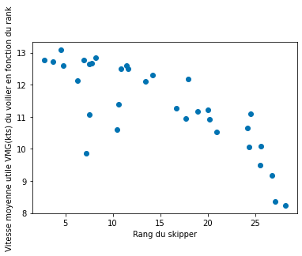

```python
plt.plot(df_skipper["rank"], df_skipper["VMG_since_last_report"], 'o')
plt.xlabel('Rang du skipper')
plt.ylabel('Vitesse moyenne utile VMG(kts) du voilier en fonction du rank');
```

on voit que la courbe est decroissante ainsi plus la vitesse est élevé plus le skipper est bien classé

```python
df['rank'].corr(df['VMG_since_last_report'])
```

```
-0.32164987044514776
```

```python
df.corr()
```

|  | rank | VMG_since_last_report |
| --- | --- | --- |
| rank | 1.00000 | -0.32165 |
| VMG_since_last_report | -0.32165 | 1.00000 |

on remarque cependant que la vitesse utile VMG n'est pas la seule variable determinant le rang du skipper

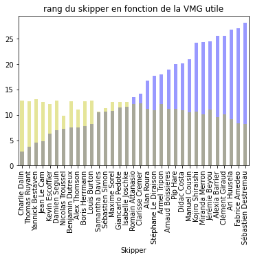

```python
plt.figure()
df_skipper["rank"].plot(kind='bar',color='b', alpha=0.4)
df_skipper["VMG_since_last_report"].plot(kind='bar',color='y', alpha=0.4)
plt.title("rang du skipper en fonction de la VMG utile")
plt.show()
```

on retrouve l'idée que plus la vitesse utile VMG est éleve meilleur est le rang, cependant d'autre facteurs comme l'itinéraire de parcours doivent également intervenir

[figure not shown]

```python
plt.figure()
sns.pairplot(pd.DataFrame(df_skipper[["rank","VMG_since_last_report"]], columns=['X1', 'X2']))
plt.title("scatter plot de covariables")
```

```python
reg = linear_model.LinearRegression()
X = df_skipper['VMG_since_last_report'].values.reshape(-1,1)
y = df_skipper["rank"].values.reshape(-1,1)
reg.fit(X, y)
print('Le score de la régression est : ',reg.score(X, y))
print('Les coeffs sont : ',reg.coef_)
print("L'intercept est : ",reg.intercept_)

x_print = df_skipper["rank"]
y_print = reg.coef_[0]*df_skipper["rank"]+reg.intercept_
```

```
Le score de la régression est :  0.631799426739936
Les coeffs sont :  [[-4.742163]]
L'intercept est :  [68.61718123]
```

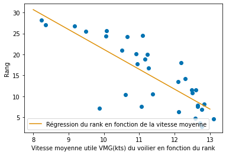

```python
x_reg = np.linspace(8,13,100)
y_reg = reg.coef_[0]*x_reg+reg.intercept_
plt.plot(X, y,'o')
plt.plot(x_reg, y_reg, label='Régression du rank en fonction de la vitesse moyenne')
plt.ylabel('Rang')
plt.xlabel('Vitesse moyenne utile VMG(kts) du voilier en fonction du rank')
plt.legend();
```

# impact du foil sur le classement et la vitesse des voiliers

on compare avec et sans foil pour voir l'impact au niveau des vitesses

```python
df_derive = df_skipper.reset_index().merge(df_boat)[['Nombre de dérives', 'rank', 'VMG_since_last_report']]
```

```python
df_derive_foil
```

[output not shown]

```python
df_derive_foil=df_derive[df_derive["Nombre de dérives"]=="foils"]
```

```python
df_derive_sans_foil=df_derive[df_derive["Nombre de dérives"]!="foils"]
```

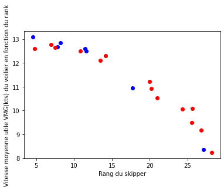

```python
plt.plot(df_derive_foil["rank"], df_derive_foil["VMG_since_last_report"], 'o', color='b', label='boat avec foil')
plt.plot(df_derive_sans_foil["rank"], df_derive_sans_foil["VMG_since_last_report"], 'o', color='r', label='boat sans foil')
plt.xlabel('Rang du skipper')
plt.ylabel('Vitesse moyenne utile VMG(kts) du voilier en fonction du rank');
```

# Variable d'importances PCA

On essaie d'appliquer la PCA au foil pour voir si ce sont des variables d'importances

```python
from sklearn.decomposition import PCA
pca = PCA(n_components=2)
#mappage des valeurs
df_derive.dropna(inplace=True)
df_derive['Nombre de dérives'] = df_derive["Nombre de dérives"].map({True: 1, False: 0})
df_derive.dropna(inplace=True)
X = df_derive[['VMG_since_last_report', "Nombre de dérives"]].to_numpy()
pca.fit(X)
print("variance pca " ,pca.explained_variance_ratio_)
```

[output not shown]

# Analyse de serie temporelle

l'importation nous a permis d'avoir une colonne correspondant au temps ce qui facilite l'analyse temporelle on peut ainsi ploter l'evolution du rang en fonction du temps

```python
pd.to_datetime(df["heure_bis"], format='%Y-%m-%d_%H:%M:%S')
```

```
0       2020-11-08 14:00:00
1       2020-11-08 14:00:00
2       2020-11-08 14:00:00
3       2020-11-08 14:00:00
4       2020-11-08 14:00:00
                ...
12133   2021-01-07 14:00:00
12134   2021-01-07 14:00:00
12135   2021-01-07 14:00:00
12136   2021-01-07 14:00:00
12137   2021-01-07 14:00:00
Name: heure_bis, Length: 10831, dtype: datetime64[ns]
```

```python
df_name= df.groupby(['Skipper'])
```

```python
df_name.head()
```

|  | rank | nat_sail | hour_FR | latitude | longitude | heading_since_30_mn | speed_since_30_mn | VMG_since_30_mn | distance_since_30_mn | heading_since_last_report | ... | distance_since_last_report | heading_since_24_hr | speed_since_24_hr | VMG_since_24_hr | distance_since_24_hr | DTF | DTL | heure_bis | Skipper | Crew |
| --- | --- | --- | --- | --- | --- | --- | --- | --- | --- | --- | --- | --- | --- | --- | --- | --- | --- | --- | --- | --- | --- |
| 0 | 1 | FRA 18 | 15:30 | 46°24.46'N | 01°50.48'W | 241 | 17.7 | 17.5 | 0.3 | 357 | ... | 2788.0 | 201 | 0.3 | 0.3 | 6.1 | 24293.9 | 0.0 | 2020-11-08_14:00:00 | Louis Burton | Bureau Vallée 2 |
| 1 | 2 | MON 10 | 15:31 1min | 46°24.34'N | 01°49.82'W | 241 | 11.1 | 10.9 | 0.4 | 357 | ... | 2787.9 | 196 | 0.3 | 0.2 | 6.0 | 24294.2 | 0.4 | 2020-11-08_14:00:00 | Boris Herrmann | Seaexplorer - Yacht Club De Monaco |
| 2 | 3 | FRA 8 | 15:30 | 46°24.91'N | 01°49.99'W | 244 | 15.5 | 15.5 | 0.5 | 357 | ... | 2788.5 | 199 | 0.2 | 0.2 | 5.5 | 24294.3 | 0.5 | 2020-11-08_14:00:00 | Jérémie Beyou | Charal |
| 3 | 4 | FRA 59 | 15:30 | 46°24.71'N | 01°49.68'W | 244 | 13.2 | 13.1 | 0.7 | 357 | ... | 2788.3 | 196 | 0.2 | 0.2 | 5.6 | 24294.5 | 0.6 | 2020-11-08_14:00:00 | Thomas Ruyant | LinkedOut |
| 4 | 5 | FRA 53 | 15:30 | 46°24.59'N | 01°49.56'W | 246 | 10.9 | 10.9 | 0.2 | 357 | ... | 2788.1 | 195 | 0.8 | 0.7 | 5.8 | 24294.5 | 0.6 | 2020-11-08_14:00:00 | Maxime Sorel | V And B Mayenne |
| ... | ... | ... | ... | ... | ... | ... | ... | ... | ... | ... | ... | ... | ... | ... | ... | ... | ... | ... | ... | ... | ... |
| 164 | 33 | FRA 56 | 05:30 | 46°29.32'N | 01°47.21'W | 215 | 0.0 | 0.0 | 0.0 | 87 | ... | 29.4 | 176 | 0.0 | 0.0 | 0.8 | 24298.2 | 165.1 | 2020-11-09_04:00:00 | Fabrice Amedeo | Newrest - Art et Fenetres |
| 184 | 20 | FRA 14 | 09:00 | 46°26.61'N | 06°55.92'W | 289 | 11.6 | 1.6 | 5.8 | 283 | ... | 37.9 | 267 | 8.9 | 7.9 | 212.6 | 24144.0 | 33.0 | 2020-11-09_08:00:00 | Arnaud Boissieres | La Mie Câline - Artisans Artipôle |
| 189 | 25 | FRA 79 | 09:00 | 46°54.58'N | 08°16.41'W | 294 | 11.9 | -0.3 | 5.9 | 294 | ... | 46.5 | 273 | 11.2 | 5.2 | 268.0 | 24147.6 | 36.5 | 2020-11-09_08:00:00 | Charlie Dalin | APIVIA |
| 227 | 30 | FRA 14 | 12:00 | 46°41.16'N | 07°32.89'W | 312 | 8.1 | -2.6 | 4.1 | 300 | ... | 29.3 | 272 | 10.0 | 4.8 | 238.9 | 24146.8 | 51.5 | 2020-11-09_11:00:00 | Arnaud Boissieres | La Mie Câline - Artisans Artipôle |
| 260 | 30 | FRA 14 | 15:00 | 46°33.44'N | 07°52.03'W | 190 | 10.2 | 9.9 | 5.1 | 239 | ... | 15.3 | 269 | 10.6 | 5.5 | 253.2 | 24134.5 | 64.0 | 2020-11-09_14:00:00 | Arnaud Boissieres | La Mie Câline - Artisans Artipôle |

165 rows × 22 columns

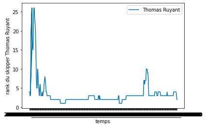

```python
rank = df['rank'].loc[(df["Skipper"] == "Thomas Ruyant")]
temps = df['heure_bis'].loc[(df["Skipper"] == "Thomas Ruyant")]
plt.plot(temps, rank, label = "Thomas Ruyant")
plt.xlabel("temps")
plt.ylabel("rank du skipper Thomas Ruyant")
plt.legend()
```

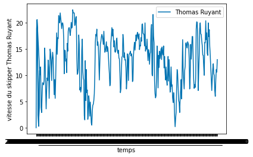

```python
vitesse = df['VMG_since_last_report'].loc[(df["Skipper"] == "Thomas Ruyant")]
temps = df['heure_bis'].loc[(df["Skipper"] == "Thomas Ruyant")]
plt.plot(temps, vitesse, label = "Thomas Ruyant")
plt.xlabel("temps")
plt.ylabel("vitesse du skipper Thomas Ruyant")
plt.legend()
```

le deuxieme skipper a un mauvais classement malgré une bonne vitesse en debut de course, il arrive également à maintenir son rang malgré une chute de vitesse en fin de premiere partie de course

il peut également etre interesant de comparer le profil des premiers skipper

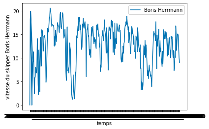

```python
vitesse = df['VMG_since_last_report'].loc[(df["Skipper"] == "Boris Herrmann")]
temps = df['heure_bis'].loc[(df["Skipper"] == "Boris Herrmann")]
plt.plot(temps, vitesse, label = "Boris Herrmann")
plt.xlabel("temps")
plt.ylabel("vitesse du skipper Boris Herrmann")
plt.legend()
```

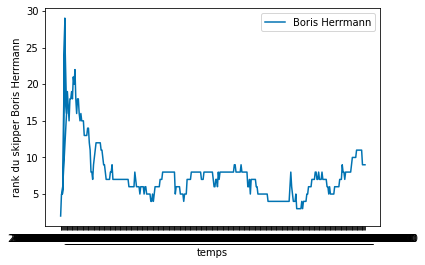

```python
rank = df['rank'].loc[(df["Skipper"] == "Boris Herrmann")]
temps = df['heure_bis'].loc[(df["Skipper"] == "Boris Herrmann")]
plt.plot(temps, rank, label = "Boris Herrmann")
plt.xlabel("temps")
plt.ylabel("rank du skipper Boris Herrmann")
plt.legend()
```

il est interessant de voir que les skipper ont des profils de vitesse similaires et rank assez proche

on remarque également que la première partie de course est peu importante ou decisive par rapport à l'issue finale

# DISTANCE EN FONCTION DU TEMPS

[figure not shown]

```python
DISTANCE = df['distance_since_last_report'].loc[(df["Skipper"] == "Boris Herrmann")]
temps = df['heure_bis'].loc[(df["Skipper"] == "Boris Herrmann")]
plt.plot(temps, DISTANCE, '.', label = "Boris Herrmann")
plt.title("distance en fonction du temps Boris Herrmann")
plt.xlabel("temps")
plt.ylabel("DISTANCE du skipper Boris Herrmann")
plt.legend()
```